# Lab 9: CNL and Count Models

Mateo Villamizar Chaparro

10/15/2020

## **Important Information**:

1. **Office hours**: Tuesdays from 4:00-5:00 pm (https://duke.zoom.us/j/94327288065)
2. **Labs**: Fridays from 10:15-11:30 (https://duke.zoom.us/j/93156474311)

## **Some things about HW2 and the first short paper**

1. Take the exercise of the short paper seriously. Look at papers in your field/subfield that use these methods and see how they are presented. Take a closer look at how they present tables and graphs and their discussions about the strengths and weaknesses from their models
2. For the short paper, any substantive comments on your theory, would not reduce your grade. They are just comments on what you are writing that I found interesting to flag, since these are topics some of you want to keep working on.

## **CNL using mlogit**

Let’s continue the analysis of transportation choices from last lab. Here we are running a conditional logit where we include the cost and wait time for each choice in addition to travelling party characteristics.

```r
# Call the data
data("TravelMode", package = "AER")
data <- TravelMode

# Estimate the model
mnl2 <- mlogit(choice ~ wait + vcost | income + size , data = data)
summary(mnl2)
```

```
##
## Call:
## mlogit(formula = choice ~ wait + vcost | income + size, data = data,
##     method = "nr")
##
## Frequencies of alternatives:choice
##     air   train     bus     car
## 0.27619 0.30000 0.14286 0.28095
##
## nr method
## 5 iterations, 0h:0m:0s
## g'(-H)^-1g = 7.74E-08
## gradient close to zero
##
## Coefficients :
##                      Estimate  Std. Error z-value  Pr(>|z|)
## (Intercept):train -2.21729746  0.88251871 -2.5125 0.0119891 *
## (Intercept):bus   -3.19369558  1.01810790 -3.1369 0.0017075 **
## (Intercept):car   -7.66503140  1.10506022 -6.9363 4.025e-12 ***
## wait              -0.10288774  0.01146298 -8.9757 < 2.2e-16 ***
## vcost             -0.00075435  0.00726231 -0.1039 0.9172707
## income:train      -0.06537273  0.01578416 -4.1417 3.448e-05 ***
## income:bus        -0.02631247  0.01653268 -1.5915 0.1114875
## income:car        -0.00048884  0.01250270 -0.0391 0.9688116
## size:train         1.05016792  0.31168792  3.3693 0.0007536 ***
## size:bus           0.67378173  0.39508356  1.7054 0.0881169 .
## size:car           0.84219465  0.27427257  3.0706 0.0021359 **
## ---
## Signif. codes:  0 '***' 0.001 '**' 0.01 '*' 0.05 '.' 0.1 ' ' 1
##
## Log-Likelihood: -184.51
## McFadden R^2:  0.34977
## Likelihood ratio test : chisq = 198.5 (p.value = < 2.22e-16)
```

```r
# In case your data is not in the apropriate format you can use the mlogit.data command. Two tips when using this command. First, the command asks for the information of your actual dataset and it will convert it into a mlogit friendly format. So the options of the function are the characteristics of you original data. Second, make sure that the choice varying variables have a "prefix" that is clearly separable. In this case use ".", ",", "-", "_". This way it is easier for the command to work. Always use ?mlogit.data for addiitonal help.

# Simmulate the data from a multivariate normal distribution
gamma <- mnl2$coefficients
V <- solve(-mnl2$hessian)

# Simulation
nsim <- 1000
set.seed(1234)
S <- mvrnorm(nsim, mu = gamma, Sigma = V)
head(S)
```

```
##      (Intercept):train (Intercept):bus (Intercept):car        wait
## [1,]      -1.562942892       -2.367612       -5.822320 -0.08536654
## [2,]      -2.551357667       -3.329803       -8.031988 -0.10980509
## [3,]      -3.070657013       -4.814412       -8.213828 -0.09465991
## [4,]       0.005267979       -1.160565       -5.637583 -0.09819696
## [5,]      -3.287423927       -3.326855       -7.953722 -0.11124007
## [6,]      -2.805231652       -4.323877       -7.322448 -0.09978649
##              vcost income:train   income:bus   income:car size:train
## [1,]  0.0056941697  -0.05884922 -0.032100824 -0.013249953  0.8711523
## [2,] -0.0017329955  -0.06029038 -0.024766092  0.006644970  0.9736608
## [3,] -0.0049601758  -0.04742271 -0.003738414  0.015486956  1.0920387
## [4,]  0.0117867579  -0.07439438 -0.012181898 -0.001341453  0.2861059
## [5,]  0.0017849386  -0.03814948 -0.006035928  0.010615432  1.0174493
## [6,] -0.0005414498  -0.06555450 -0.015986904 -0.009330051  1.5003750
##         size:bus  size:car
## [1,]  0.83164545 0.7793563
## [2,]  0.65890975 0.6676530
## [3,]  1.13420812 0.9669955
## [4,] -0.59376512 0.3624798
## [5,]  0.09210749 0.7310323
## [6,]  1.05021865 0.9867028
```

```r
# Define the scenario of interest: typical case approach
train  <- c(1,0,0, mean(data[data$mode=="train","wait"]), mean(data[data$mode=="train","vcost"]), mean(data[,"income"]), 0, 0,
            mean(data[,"size"]),0,0)
bus <- c(0,1,0, mean(data[data$mode=="bus","wait"]), mean(data[data$mode=="bus","vcost"]), 0, mean(data[,"income"]), 0,
            0,mean(data[,"size"]),0)
car <- c(0,0,1, mean(data[data$mode=="car","wait"]), mean(data[data$mode=="car","vcost"]), 0, 0, mean(data[,"income"]),
            0,0,mean(data[,"size"]))
air <- c(0,0,0, mean(data[data$mode=="air","wait"]), mean(data[data$mode=="air","vcost"]), 0, 0, 0,0,0,0)

# calculating linear predictors
theta_t <- S %*% train
theta_b <- S %*% bus
theta_c <- S %*% car
theta_a <- S %*% air

# Calculate the denominator
denom = exp(theta_t) + exp(theta_b) + exp(theta_c) + exp(theta_a)

# Calculate the expected values
ev_train <- exp(theta_t)/denom
ev_bus <- exp(theta_b)/denom
ev_car <- exp(theta_c)/denom
ev_air <- exp(theta_a)/denom

# Set a placeholder matrix
ev <- matrix(NA, 4,3)
ev[1,1] <- mean(ev_train)
ev[2,1] <- mean(ev_bus)
ev[3,1] <- mean(ev_car)
ev[4,1] <- mean(ev_air)
ev[1,2:3] <- quantile(ev_train, c(.025,.975))
ev[2,2:3] <- quantile(ev_bus, c(.025,.975))
ev[3,2:3] <- quantile(ev_car, c(.025,.975))
ev[4,2:3] <- quantile(ev_air, c(.025,.975))
rownames(ev) <- c("Train", "Bus", "Car", "Air")
colnames(ev) <- c("Mean", "Low CI", "High CI")
round(ev, 2)
```

```
##       Mean Low CI High CI
## Train 0.28   0.20    0.37
## Bus   0.12   0.07    0.18
## Car   0.32   0.25    0.40
## Air   0.28   0.20    0.37
```

```r
# Using predict
t_wait <- seq(0,100, 10)
ev1 <- matrix(NA, length(t_wait),12)
for (i in 1:length(t_wait)) {
  XN <- data
  XN[XN$mode=="air","wait"] <- t_wait[i]
  XN[XN$mode=="train","wait"] <- mean(data[data$mode=="train","wait"])
  XN[XN$mode=="bus","wait"] <- mean(data[data$mode=="bus","wait"])
  XN[XN$mode=="car","wait"] <- mean(data[data$mode=="car","wait"])
  ev1[i,1:4] <- apply(predict(mnl2, newdata = XN, type = "probs"), 2, mean)
  ev1[i,5:8] <- apply(predict(mnl2, newdata = XN, type = "probs"), 2, quantile, probs=c(0.05))
  ev1[i,9:12] <- apply(predict(mnl2, newdata = XN, type = "probs"), 2, quantile, probs=c(0.975))
}
colnames(ev1) <- c("Air", "Train", "Bus", "Car", "lo_ai", "lo_tr", "lo_bu", "lo_ca","hi_ai", "hi_tr", "hi_bu", "hi_car")
round(ev1, 3)
```

```
##         Air Train   Bus   Car lo_ai lo_tr lo_bu lo_ca hi_ai hi_tr hi_bu hi_car
##  [1,] 0.990 0.006 0.001 0.003 0.963 0.000 0.000 0.001 0.999 0.033 0.004  0.014
##  [2,] 0.974 0.014 0.003 0.009 0.903 0.000 0.001 0.003 0.996 0.086 0.010  0.036
##  [3,] 0.935 0.035 0.007 0.023 0.769 0.001 0.002 0.008 0.989 0.200 0.024  0.093
##  [4,] 0.856 0.075 0.017 0.052 0.543 0.003 0.005 0.021 0.969 0.373 0.042  0.213
##  [5,] 0.718 0.141 0.035 0.107 0.299 0.009 0.013 0.047 0.919 0.488 0.063  0.395
##  [6,] 0.522 0.227 0.063 0.189 0.132 0.022 0.032 0.084 0.802 0.621 0.085  0.469
##  [7,] 0.313 0.309 0.094 0.284 0.052 0.044 0.063 0.115 0.592 0.716 0.114  0.619
##  [8,] 0.153 0.365 0.119 0.363 0.019 0.061 0.079 0.132 0.341 0.759 0.150  0.721
##  [9,] 0.064 0.394 0.134 0.408 0.007 0.070 0.080 0.134 0.156 0.772 0.173  0.777
## [10,] 0.024 0.407 0.140 0.429 0.002 0.074 0.081 0.135 0.062 0.775 0.185  0.798
## [11,] 0.009 0.411 0.142 0.437 0.001 0.075 0.081 0.135 0.023 0.777 0.189  0.805
```

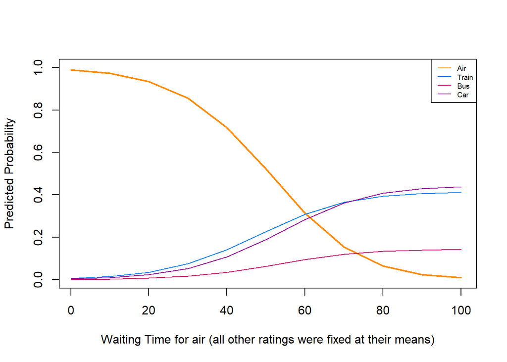

```r
# plotting the results
plot(t_wait, ev1[, 1], type = 'l', lwd = 2, col = "#ff8c00",
     ylab = "Predicted Probability",
     xlab = "Waiting Time for air (all other ratings were fixed at their means)",
     xlim=c(1,100), ylim=c(0,1))
lines(t_wait, ev1[,2], type = 'l', col="#007df6")
lines(t_wait, ev1[,3], type = 'l', col="#CC0066")
lines(t_wait, ev1[,4], type = 'l', col="#940094")
legend("topright", legend=c("Air", "Train", "Bus", "Car"),
       col=c("#ff8c00","#007df6", "#CC0066", "#940094"), lty=1, cex=0.6)
```

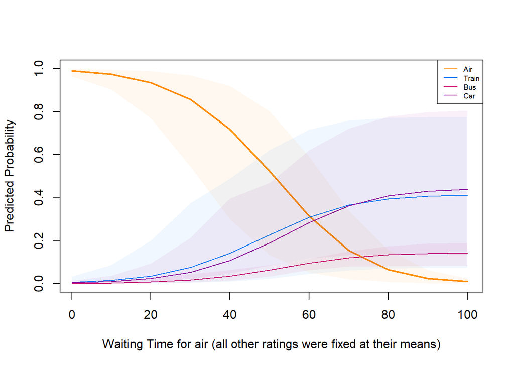

```r
# plotting with confidence intervals
plot(t_wait, ev1[, 1], type = 'l', lwd = 2, col = "#ff8c00",
     ylab = "Predicted Probability",
     xlab = "Waiting Time for air (all other ratings were fixed at their means)",
     xlim=c(1,100), ylim=c(0,1))
lines(t_wait, ev1[,2], type = 'l', col="#007df6")
lines(t_wait, ev1[,3], type = 'l', col="#CC0066")
lines(t_wait, ev1[,4], type = 'l', col="#940094")
legend("topright", legend=c("Air", "Train", "Bus", "Car"),
       col=c("#ff8c00","#007df6", "#CC0066", "#940094"), lty=1, cex=0.6)
x <- c(t_wait, rev(t_wait))
ytr <- c(ev1[,5], rev(ev1[,9]))
polygon(x, ytr, col = "#ff8c000f", border = FALSE)
ybu <- c(ev1[,6], rev(ev1[,10]))
polygon(x, ybu, col = "#007df60f", border = FALSE)
yca <- c(ev1[,7], rev(ev1[,11]))
polygon(x, yca, col = "#CC00660f", border = FALSE)
yai <- c(ev1[,8], rev(ev1[,12]))
polygon(x, yai, col = "#9400940f", border = FALSE)
```

## **Count Models**

### *What are count variables?*

Count variables are pretty common in Political Science and they recall the number of events that happened during a specific period of time. There are two main characteristics of this type of data. First, it is **discrete** which means we only have integers. Second, it is **bounded from below** which means that you can’t have negative numbers. These two characteristics are important as they will help us determine the best distribution that approximates this data. Although there are some distributions that can model this type of data, the most common one is a **Poisson distribution**.

*Why not use OLS?* Well, by know you should know the two main objections: predictions out of bounds (decimals and negative numbers in this case) and the fact that the model will suffere from heteroskedasticity since the variance will depend on the mean. Some scholar try to avoid this issues by using log-transformations of the DV. However, here scholars need to make an assumption of how to deal with zeros in the data. But even this transformation will have its set backs. Think aout what some of them could be.

### *How do we construct the model*

We have derived the log-likelihood function for a Poisson distribution before. See [lab 4](https://github.com/sanmavicha/MLE_Lab/tree/master/Lab4). So, I’m not going into details here. The model we will be calculating is:

$$\begin{split}
Y \sim Poisson(\mu_i) &= \frac{e^{-\mu_i}\mu_i^{y_i}}{y_i!} \\
\\
\mu_i &= e^{X_i\beta}
\end{split}$$
The log-likelihood function is:

$$ll(\mu|y) = \sum_{i=1}^n y_i \ln \mu-\sum_{i=1}^n\ln(y_i!) -\mu n \\$$

Some assumptions from the Poisson model: + Infinitesimal interval + No simultaneity of events + IID

### *Our dataset*

Given that some of you are very interested in international security issues we are not going to use the published articles dataset from the AER. Instead, for today’s lab we are going to use a dataset from [Wilson and Piazza (2013)](https://onlinelibrary.wiley.com/doi/pdf/10.1111/ajps.12028?casa_token=v5vMx_STXzwAAAAA:-Zb1lwc6e7yAhjTxFdxSujDkx2fSBhCk8qBmXbPl_msrNnocNjWMKRDsiJK9oRGNudgKYbh5f4Id). A copy of the data used in this paper can be found in a txt format in excel. The refime data is taken from Barbara Geddes’ work and the base category are military authoritarian regimes. The main variables are:

```r
#terrorism <- read.table("wilsonpiazzavars_r.txt", head=T)      # Notice we use read.table for txt files
#colnames(terrorism)[13:17] <- c("democracy","personalist","oneparty","monarchy","hybrid")
#colnames(terrorism)[11:12] <- c("dome_confl", "inal_confl")
#terrorism <- terrorism[-3]
#write.table(terrorism, "wilsonpiazzavars.txt", col.names = T)
terrorism <- read.table("wilsonpiazzavars.txt", head=T)      # Notice we use read.table for txt files
summary(terrorism)
```

```
##      ccode            year         Durable            GINI
##  Min.   :  2.0   Min.   :1970   Min.   :  0.00   Min.   :17.80
##  1st Qu.:220.0   1st Qu.:1979   1st Qu.:  5.00   1st Qu.:37.00
##  Median :439.0   Median :1988   Median : 14.00   Median :45.10
##  Mean   :439.7   Mean   :1987   Mean   : 23.47   Mean   :43.93
##  3rd Qu.:640.0   3rd Qu.:1996   3rd Qu.: 31.00   3rd Qu.:50.60
##  Max.   :950.0   Max.   :2004   Max.   :195.00   Max.   :84.80
##      logGNI           logpop          logarea           AggSF
##  Min.   : 3.904   Min.   :-2.120   Min.   : 5.756   Min.   : 0.0000
##  1st Qu.: 5.948   1st Qu.: 1.163   1st Qu.:11.179   1st Qu.: 0.0000
##  Median : 6.987   Median : 2.048   Median :12.395   Median : 0.0000
##  Mean   : 7.225   Mean   : 2.067   Mean   :12.173   Mean   : 0.5741
##  3rd Qu.: 8.334   3rd Qu.: 3.047   3rd Qu.:13.515   3rd Qu.: 0.0000
##  Max.   :14.102   Max.   : 7.164   Max.   :16.648   Max.   :13.5000
##     ColdWar         dome_confl        inal_confl       democracy
##  Min.   :0.0000   Min.   :0.00000   Min.   :0.0000   Min.   :0.0000
##  1st Qu.:0.0000   1st Qu.:0.00000   1st Qu.:0.0000   1st Qu.:0.0000
##  Median :1.0000   Median :0.00000   Median :0.0000   Median :0.0000
##  Mean   :0.5806   Mean   :0.09332   Mean   :0.3116   Mean   :0.4586
##  3rd Qu.:1.0000   3rd Qu.:0.00000   3rd Qu.:0.0000   3rd Qu.:1.0000
##  Max.   :1.0000   Max.   :3.00000   Max.   :3.0000   Max.   :1.0000
##   personalist        oneparty         monarchy           hybrid
##  Min.   :0.0000   Min.   :0.0000   Min.   :0.00000   Min.   :0.00000
##  1st Qu.:0.0000   1st Qu.:0.0000   1st Qu.:0.00000   1st Qu.:0.00000
##  Median :0.0000   Median :0.0000   Median :0.00000   Median :0.00000
##  Mean   :0.1343   Mean   :0.2372   Mean   :0.06036   Mean   :0.03007
##  3rd Qu.:0.0000   3rd Qu.:0.0000   3rd Qu.:0.00000   3rd Qu.:0.00000
##  Max.   :1.0000   Max.   :1.0000   Max.   :1.00000   Max.   :1.00000
##     FGTDDom
##  Min.   :  0.000
##  1st Qu.:  0.000
##  Median :  0.000
##  Mean   :  8.556
##  3rd Qu.:  2.000
##  Max.   :524.000
```